# atividade4

Nilson Berriel

12/05/2022

Carregando os pacotes necessários:

```r
library(tidyverse)
library(rgbif)
```

Checando as funções:

```r
?occ_data
```

```
## starting httpd help server ... done
```

Baixando ocorrências

```r
dori_gbif <- occ_data(scientificName = "Paracanthurus hepatus",
                      hasCoordinate = TRUE,
                      hasGeospatialIssue=FALSE)
```

Vendo as dimensões dos dados:

```r
dim(dori_gbif)
```

[output not shown]

```r
dim(dori_gbif$data)
```

```
## [1] 500 154
```

Checando os campos

```r
dori_gbif$data %>% names
```

```
##   [1] "key"
##   [2] "scientificName"
##   [3] "decimalLatitude"
##   [4] "decimalLongitude"
##   [5] "issues"
##   [6] "datasetKey"
##   [7] "publishingOrgKey"
##   [8] "installationKey"
##   [9] "publishingCountry"
##  [10] "protocol"
##  [11] "lastCrawled"
##  [12] "lastParsed"
##  [13] "crawlId"
##  [14] "hostingOrganizationKey"
##  [15] "basisOfRecord"
```

[output cut: 139 more lines]

Checando os problemas reportados

```r
gbif_issues()
```

```
##           code                                             issue
## 1          bri                           BASIS_OF_RECORD_INVALID
## 2          ccm                        CONTINENT_COUNTRY_MISMATCH
## 3          cdc                CONTINENT_DERIVED_FROM_COORDINATES
## 4        conti                                 CONTINENT_INVALID
## 5         cdiv                                COORDINATE_INVALID
## 6        cdout                           COORDINATE_OUT_OF_RANGE
## 7        cdrep                            COORDINATE_REPROJECTED
## 8       cdrepf                    COORDINATE_REPROJECTION_FAILED
## 9       cdreps                COORDINATE_REPROJECTION_SUSPICIOUS
## 10     cdround                                COORDINATE_ROUNDED
## 11     cucdmis                       COUNTRY_COORDINATE_MISMATCH
## 12        cudc                  COUNTRY_DERIVED_FROM_COORDINATES
## 13        cuiv                                   COUNTRY_INVALID
## 14         cum                                  COUNTRY_MISMATCH
```

[output cut: 285 more lines]

```r
issues_gbif <- dori_gbif$data$issues %>%
  strsplit(., "[,]") %>%
  unlist() %>%
  unique()
```

Prosseguimos selecionando algumas variáveis que serão úteis para a validação dos dados e futuras análises, como coordenadas, profundidade, nome da base de dados etc.

```r
dori_gbif1 <- dori_gbif$data %>%
  dplyr::select(scientificName, acceptedScientificName, decimalLatitude, decimalLongitude,
                issues, waterBody, basisOfRecord, occurrenceStatus, rightsHolder,
                datasetName, recordedBy, depth, locality, habitat)
dori_gbif1 <- dori_gbif1 %>%
  distinct()
```

Checando os níveis dos fatores

```r
lapply(dori_gbif1, unique)
```

```
## $scientificName
## [1] "Paracanthurus hepatus (Linnaeus, 1766)"
## [2] "BOLD:AAC3227"
## [3] "BOLD:AAT9935"
##
## $acceptedScientificName
## [1] "Paracanthurus hepatus (Linnaeus, 1766)"
## [2] "BOLD:AAC3227"
## [3] "BOLD:AAT9935"
##
## $decimalLatitude
##   [1] -33.800169 -30.202839 -27.400000 -30.205483  -4.289271 -17.071277
##   [7] -28.611278  -4.656524 -17.636875  25.015492   2.728201  -4.356636
##  [13]  -6.353158  22.319095  28.169633 -14.663600   4.595825 -18.287067
##  [19] -13.647350  -8.349668  22.680278 -28.196141  26.189035  -2.244373
```

[output cut: 470 more lines]

Checando os problemas não resportados

É necessário carregar os seguintes pacotes:

```r
library(bdc)
library(CoordinateCleaner)
```

Checando as coordenadas válidas

```r
check_pf <-
  bdc::bdc_coordinates_outOfRange(
    data = dori_gbif1,
    lat = "decimalLatitude",
    lon = "decimalLongitude")
```

```
##
## bdc_coordinates_outOfRange:
## Flagged 0 records.
## One column was added to the database.
```

Vamos checar se as coordenadas estão associadas as capitais dos países:

```r
cl <- dori_gbif1 %>%
  select(acceptedScientificName, decimalLatitude, decimalLongitude) %>%
  rename(decimallongitude = decimalLongitude,
         decimallatitude = decimalLatitude,
         scientificName = acceptedScientificName) %>%
  as_tibble() %>%
  mutate(val = cc_val(., value = "flagged"),
         sea = cc_sea(., value = "flagged"),
         capital = cc_cap(., value = "flagged"))
```

```
## Testing coordinate validity
```

```
## Flagged 0 records.
```

```
## Testing sea coordinates
```

```
## Flagged 366 records.
```

```
## Testing country capitals
```

```
## Flagged 23 records.
```

Verificando as coordenadas com flags

Vamos verificar as capitais (por padrão é um raio de 10 km)

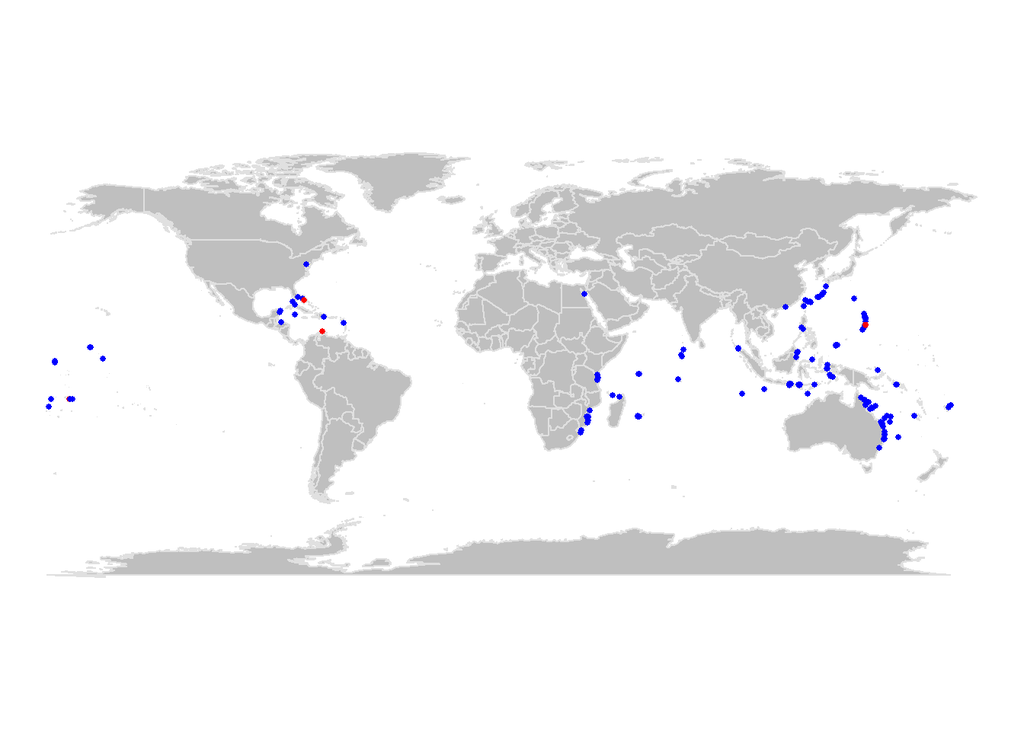

```r
cl %>%
  rename(decimalLongitude = decimallongitude,
         decimalLatitude = decimallatitude) %>%
  bdc::bdc_quickmap(., col_to_map = "capital")
```

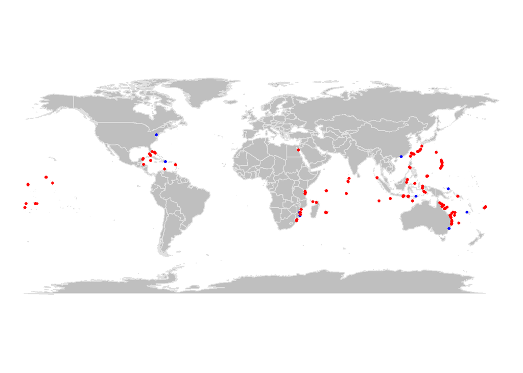

```r
cl %>%
  rename(decimalLongitude = decimallongitude,
         decimalLatitude = decimallatitude) %>%
  bdc::bdc_quickmap(., col_to_map = "sea")
```

Investigando os níveis supeitos

```r
dori_gbif1 %>%
  distinct(waterBody) %>%
  pull()
```

```
##  [1] NA
##  [2] "North Pacific Ocean"
##  [3] "Celebes Sea"
##  [4] "South Pacific Ocean"
##  [5] "Flores Sea"
##  [6] "Pacific"
##  [7] "Caribbean Sea"
##  [8] "Gulf of Mexico"
##  [9] "Atlantic Ocean"
## [10] "Verde Island"
## [11] "La Caleta"
## [12] "Red Sea"
## [13] "Carribean"
## [14] "Banda Sea"
## [15] "Indian Ocean"
## [16] "IndianOcean"
## [17] "Laut Bali"
## [18] "Royal Caribbean"
## [19] "Laccadive Sea"
## [20] "Baltimore, MD"
## [21] "Carribean Sea"
## [22] "South China and Eastern Archipelagic Seas"
```

Verificando o nível waterbody

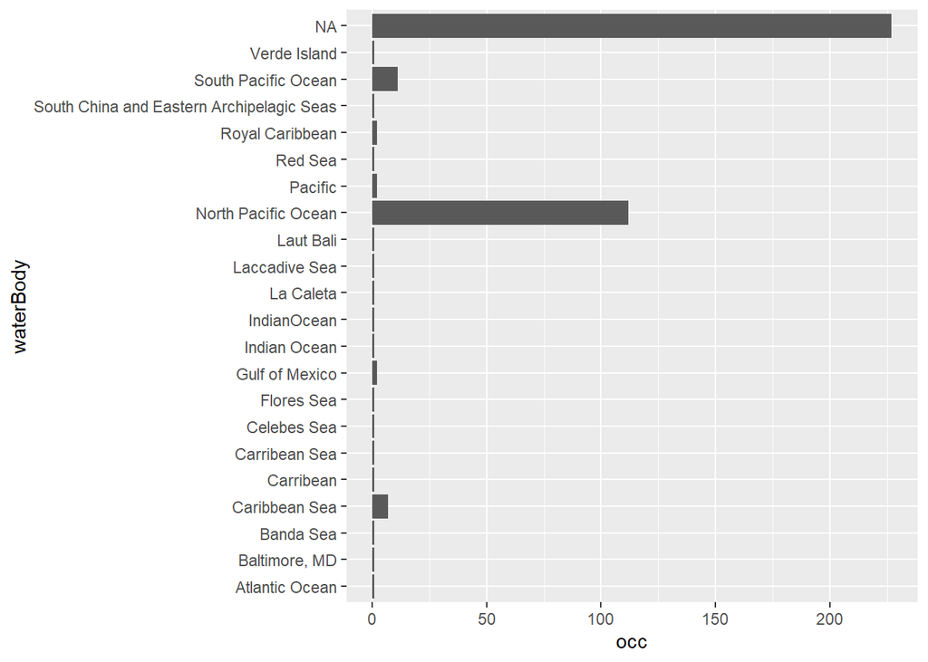

```r
dori_gbif1 %>%
  group_by(waterBody) %>%
  summarise(occ = length(scientificName)) %>%
  ggplot(aes(occ, y=waterBody)) +
  geom_bar(stat = 'identity')
```

Filtrando os locais de ocorrência natural da espécie

```r
dori_gbif1 %>%
  filter(waterBody %in% c("Atlantic Ocean", "Carribean", "Royal Caribbean", "Carribean Sea", "Bonaire")) %>%
  distinct(datasetName)
```

```
## # A tibble: 1 x 1
##   datasetName
##   <chr>
## 1 Diveboard - Scuba diving citizen science
```

buscando as ocorrências para “Diveboard - Scuba diving citizen science”

```r
dori_gbif1 %>%
  filter(datasetName %in% c("Diveboard - Scuba diving citizen science"))
```

```
## # A tibble: 25 x 14
##    scientificName       acceptedScienti~ decimalLatitude decimalLongitude issues
##    <chr>                <chr>                      <dbl>            <dbl> <chr>
##  1 Paracanthurus hepat~ Paracanthurus h~            4.11            119.  cdreps
##  2 Paracanthurus hepat~ Paracanthurus h~           -8.4             119.  cdreps
##  3 Paracanthurus hepat~ Paracanthurus h~           16.1             -61.8 cdreps
##  4 Paracanthurus hepat~ Paracanthurus h~           23.2             -81.2 cdreps
##  5 Paracanthurus hepat~ Paracanthurus h~           26.2             -80   cdreps
##  6 Paracanthurus hepat~ Paracanthurus h~           24.5             -81.9 cdreps
##  7 Paracanthurus hepat~ Paracanthurus h~           13.5             121.  cdreps
##  8 Paracanthurus hepat~ Paracanthurus h~           18.4             -69.7 cdreps
##  9 Paracanthurus hepat~ Paracanthurus h~           27.5              34.2 cdreps
## 10 Paracanthurus hepat~ Paracanthurus h~           19.3             -81.1 cdreps
## # ... with 15 more rows, and 9 more variables: waterBody <chr>,
## #   basisOfRecord <chr>, occurrenceStatus <chr>, rightsHolder <chr>,
## #   datasetName <chr>, recordedBy <chr>, depth <dbl>, locality <chr>,
## #   habitat <chr>
```

Filtrando todas as ocorrencias do dataset suspeito:

```r
dori_gbif_ok <- dori_gbif1 %>%
  filter(!datasetName %in% c("Diveboard - Scuba diving citizen science"))
```

Plotando os mapas de ocorrência da Dori

É necessário carregar os seguintes pacotes:

```r
library(ggmap)
```

```r
library(maps)
library(mapdata)
```

Vamos definir a área do mapa que queremos:

```r
world <- map_data('world')
```

Checando os pontos de ocorrência

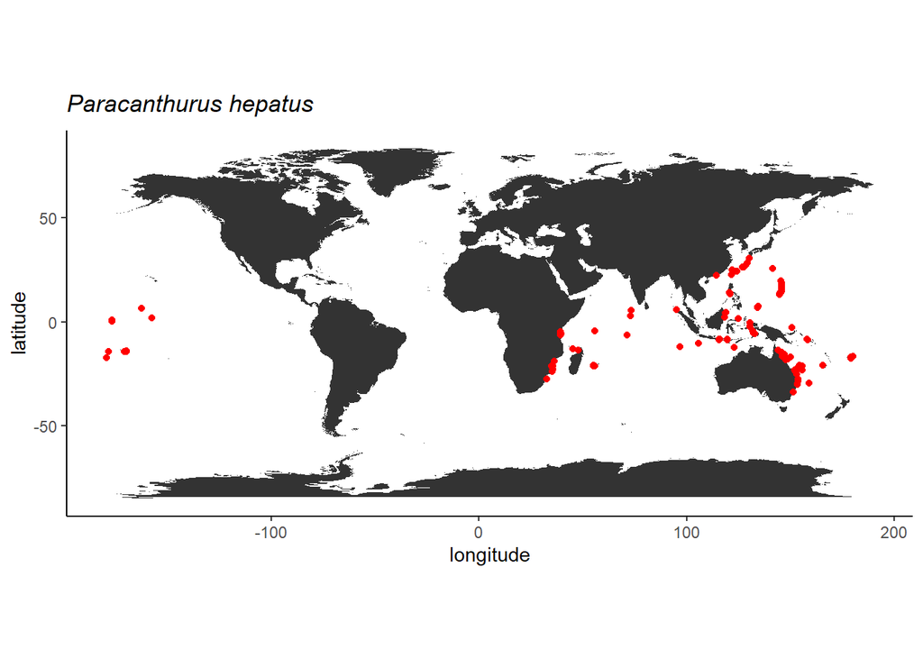

```r
ggplot() +
  geom_polygon(data = world, aes(x = long, y = lat, group = group)) +
  coord_fixed() +
  theme_classic() +
  geom_point(data = dori_gbif_ok, aes(x = decimalLongitude, y = decimalLatitude), color = "red") +
  labs(x = "longitude", y = "latitude", title = expression(italic("Paracanthurus hepatus")))
```

Checando a profundidade das ocorrências:

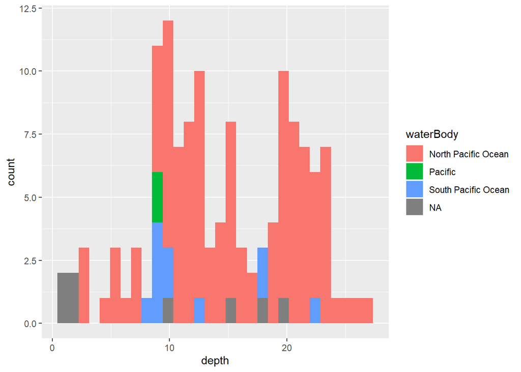

```r
dori_gbif_ok %>%
  ggplot(aes(x = depth, fill = waterBody)) +
  geom_histogram()
```

A seguir vamos utilizar os dados disponibilizados pela plataforma OBIS. Primeiramente vamos carregar o pacote necessário:

```r
library(robis)
```

Selecionando os dados da espécie utilizada:

```r
dori_obis <- robis::occurrence("Paracanthurus hepatus")
```

```
## Retrieved 551 records of approximately 551 (100%)
```

Checandos os dados:

```r
names(dori_obis)
```

```
##   [1] "rightsHolder"
##   [2] "infraphylum"
##   [3] "country"
##   [4] "date_year"
##   [5] "institutionID"
##   [6] "scientificName"
##   [7] "individualCount"
##   [8] "dropped"
##   [9] "gigaclassid"
##  [10] "aphiaID"
##  [11] "language"
##  [12] "decimalLatitude"
##  [13] "subclassid"
##  [14] "type"
##  [15] "gigaclass"
```

[output cut: 134 more lines]

```r
dori_obis1 <- dori_obis %>%
  dplyr::select(scientificName, decimalLatitude, decimalLongitude, bathymetry,
                flags, waterBody, basisOfRecord, occurrenceStatus, rightsHolder,
                datasetName, recordedBy, depth, locality, habitat) %>%
  distinct()
```

Checando os problemas reportados (flags):

```r
dori_obis1 %>%
  distinct(flags)
```

```
## # A tibble: 7 x 1
##   flags
##   <chr>
## 1 NO_DEPTH,ON_LAND
## 2 NO_DEPTH
## 3 <NA>
## 4 ON_LAND,NO_DEPTH
## 5 ON_LAND
## 6 DEPTH_EXCEEDS_BATH
## 7 ON_LAND,DEPTH_EXCEEDS_BATH
```

Checando os possíveis NAs em datasetName

```r
dori_obis1 %>%
  filter(!flags %in% c("no_depth,on_land", "on_land", "on_land,depth_exceeds_bath", "depth_exceeds_bath,on_land"),
         is.na(datasetName)) %>%
  distinct(waterBody)
```

```
## # A tibble: 12 x 1
##    waterBody
##    <chr>
##  1 <NA>
##  2 Oceania
##  3 Pacific Ocean
##  4 Asia
##  5 Africa
##  6 Indian
##  7 indien
##  8 North America Atlantic
##  9 Pacific
## 10 pacifique
## 11 atlantique
## 12 North America
```

Checando depth

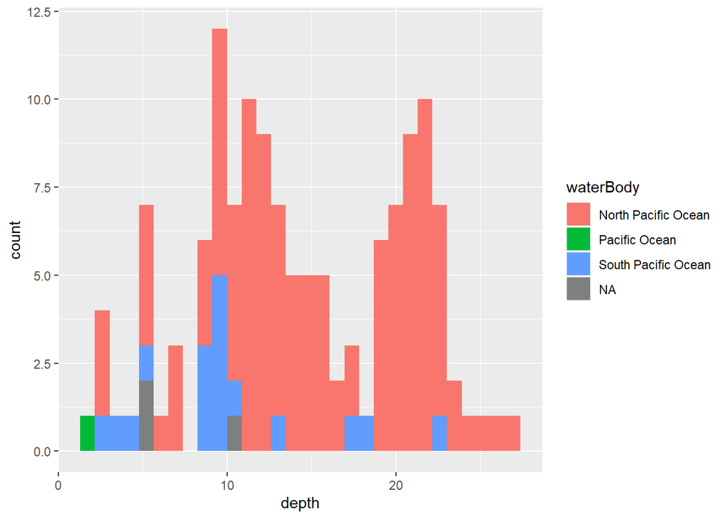

```r
dori_obis1 %>%
  filter(!flags %in% c("no_depth,on_land", "on_land", "on_land,depth_exceeds_bath", "depth_exceeds_bath,on_land"),
         !is.na(datasetName),
         !waterBody %in% c("North America", "North America Atlantic", "atlantique")) %>%
  ggplot(aes(x = depth, fill = waterBody)) +
  geom_histogram()
```

Checando os níveis

```r
dori_obis1 %>%
  filter(!flags %in% c("no_depth,on_land", "on_land", "on_land,depth_exceeds_bath", "depth_exceeds_bath,on_land"),
         !is.na(datasetName),
         !waterBody %in% c("North America", "North America Atlantic", "atlantique")) %>%
  lapply(., unique)
```

```
## $scientificName
## [1] "Paracanthurus hepatus"
##
## $decimalLatitude
##   [1]  -6.8000000  15.2612250  15.0777326  14.9315443   0.1868800   0.1915569
##   [7]  14.8471569  18.1697050  13.2303711  15.2735300   0.1882000   0.1902900
##  [13]  18.0501780  14.8436598  15.2812907   0.1908500 -14.2790305  15.0695718
##  [19]  15.1052253  20.9260006   0.2065500  14.2014619  15.2688078   0.1872420
##  [25]  15.0865944  15.0033074  15.1110520   0.1949556 -11.6506000  15.0520660
##  [31]  15.2829550  14.9524648  15.1924560  15.0912826  14.1692040  14.1088820
##  [37]   0.7982430 -14.2738570  18.1449870  14.8649172 -14.1518635  -8.4156407
##  [43]  14.9276330 -17.1836910  15.1138340  16.7184000  13.2823530  15.1163631
##  [49] -14.2240685  14.9249980  15.2766544  15.0042435  15.2748410   0.1903102
##  [55]  18.0939460  14.8389450   0.8208993  15.2542167  15.2567141  14.9349439
##  [61]  -8.4180000  17.5869300  15.1342100  14.2460003   2.1641140 -18.1486000
```

[output cut: 127 more lines]

OS dados estão ok, vamos seguir para produção do mapa

```r
dori_obis_ok <- dori_obis1 %>%
  filter(!flags %in% c("no_depth,on_land", "on_land", "on_land,depth_exceeds_bath", "depth_exceeds_bath,on_land"),
         !is.na(datasetName),
         !waterBody %in% c("North America", "North America Atlantic", "atlantique", NA))
```

Plotando o mapa

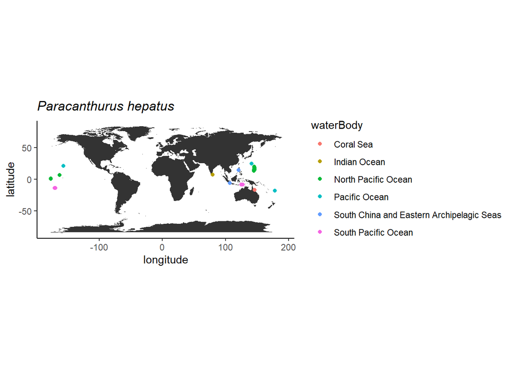

```r
ggplot() +
  geom_polygon(data = world, aes(x = long, y = lat, group = group)) +
  coord_fixed() +
  theme_classic() +
  geom_point(data = dori_obis_ok, aes(x = decimalLongitude, y = decimalLatitude, color = waterBody)) +
  labs(x = "longitude", y = "latitude", title = expression(italic("Paracanthurus hepatus")))
```